# Practical Machine Learning Project

Adrian Badica

Saturday, November 22, 2014

### Executive Summary

The goal of this report is to use machine learning algorithms and methods in order to best classify if activities recorded from a group of volunteers were executed correctly or not. The dataset that will be used comes from http://groupware.les.inf.puc-rio.br/har.

Decision trees and random forests were used to build the predictive models. The one relying on the random forest algorithm was chosen dueto the smallest out of sample error rate.

### 1. Data loading, Data Processing, Cross Validation

First we will load the data into R :

```r
set.seed(1)
training <- read.csv("http://d396qusza40orc.cloudfront.net/predmachlearn/pml-training.csv", header=TRUE, sep=",", na.strings=c("","#DIV/0!","NA"))
test <- read.csv("http://d396qusza40orc.cloudfront.net/predmachlearn/pml-testing.csv", header=TRUE, sep=",", na.strings=c("","#DIV/0!","NA"))
dim(training)
```

```
## [1] 19622   160
```

Taking a first look at the dataset we observe that there many columns with mostly missing values. We will drop these columns from the dataframe. We will also check if there are any variables with near zero variance. We will discard columns with no usable prediction value (such as the index, etc.) to create the tidy dataset.

```r
missingvalues <- sapply(training, function(x) sum(is.na(x)))
tmp <- training
tmp <- tmp[,-which(as.numeric(colSums(is.na(tmp)))>1)]
dim(tmp)
```

```
## [1] 19622    60
```

```r
require(caret)
nzv <- nearZeroVar(tmp,saveMetrics=TRUE)
View(nzv)
```

```r
dataset <- tmp[,-c(1,3,4,5,6,7)]
```

For cross validation we will randomly split the newly created dataset into a training and a test set. The test set will be used to test the accuracy of our models.

```r
library(caret)
inTrain <- createDataPartition(dataset$classe, p=0.7, list=FALSE)
training_set <- dataset[inTrain,]
test_set <- dataset[-inTrain,]
```

### 2.Prediction Models

The first model that we will build uses decision trees :

```r
library(caret)
modFit <- train(classe~., method="rpart", data=training_set)
print(modFit$finalModel)
```

```
## n= 13737
##
## node), split, n, loss, yval, (yprob)
##       * denotes terminal node
##
##  1) root 13737 9831 A (0.28 0.19 0.17 0.16 0.18)
##    2) roll_belt< 130.5 12560 8663 A (0.31 0.21 0.19 0.18 0.11)
##      4) pitch_forearm< -33.95 1101    7 A (0.99 0.0064 0 0 0) *
##      5) pitch_forearm>=-33.95 11459 8656 A (0.24 0.23 0.21 0.2 0.12)
##       10) magnet_dumbbell_y< 439.5 9686 6937 A (0.28 0.18 0.24 0.19 0.1)
##         20) roll_forearm< 120.5 5969 3512 A (0.41 0.18 0.19 0.17 0.057) *
##         21) roll_forearm>=120.5 3717 2514 C (0.079 0.19 0.32 0.23 0.18) *
##       11) magnet_dumbbell_y>=439.5 1773  876 B (0.03 0.51 0.041 0.23 0.19) *
##    3) roll_belt>=130.5 1177    9 E (0.0076 0 0 0 0.99) *
```

```r
library(rattle)
```

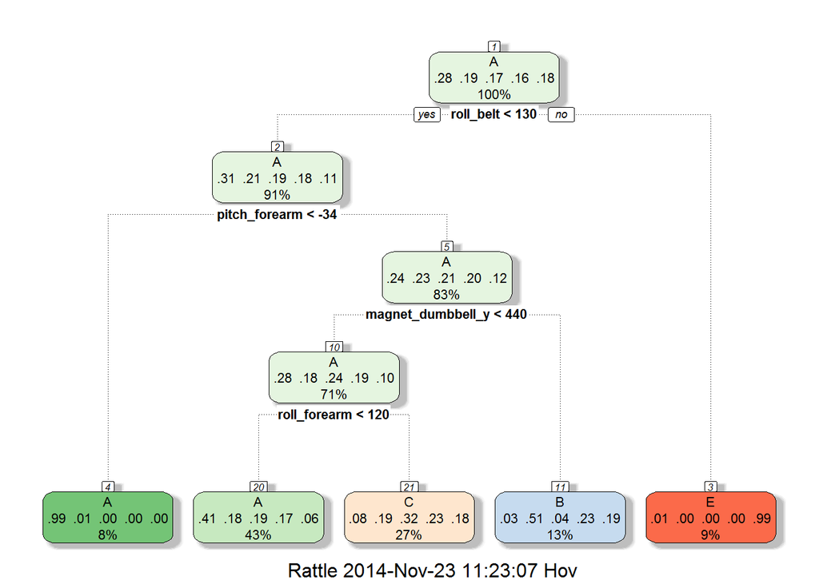

```r
fancyRpartPlot(modFit$finalModel)
```

Applying the model to the test dataset shows that the fit is poor with an out of sample error of 51%.

```r
library(caret)
pred <- predict(modFit,test_set)
confusionMatrix(pred,test_set$classe)
```

```
## Confusion Matrix and Statistics
##
##           Reference
## Prediction    A    B    C    D    E
##          A 1510  463  462  427  179
##          B   27  389   36  163  141
##          C  132  287  528  374  299
##          D    0    0    0    0    0
##          E    5    0    0    0  463
##
## Overall Statistics
##
##                Accuracy : 0.491
##                  95% CI : (0.478, 0.504)
##     No Information Rate : 0.284
##     P-Value [Acc > NIR] : <2e-16
##
##                   Kappa : 0.335
##  Mcnemar's Test P-Value : NA
##
## Statistics by Class:
##
##                      Class: A Class: B Class: C Class: D Class: E
## Sensitivity             0.902   0.3415   0.5146    0.000   0.4279
## Specificity             0.636   0.9227   0.7753    1.000   0.9990
## Pos Pred Value          0.497   0.5146   0.3259      NaN   0.9893
## Neg Pred Value          0.942   0.8538   0.8832    0.836   0.8857
## Prevalence              0.284   0.1935   0.1743    0.164   0.1839
## Detection Rate          0.257   0.0661   0.0897    0.000   0.0787
## Detection Prevalence    0.517   0.1285   0.2753    0.000   0.0795
## Balanced Accuracy       0.769   0.6321   0.6449    0.500   0.7134
```

The next model that we will build is using the random forests algorithm :

```r
library(caret)
control <- trainControl(method="cv", number=5)
modFit2 <- train(classe~., method="rf", trControl=control, data=training_set)
print(modFit2$finalModel)
```

```
##
## Call:
##  randomForest(x = x, y = y, mtry = param$mtry)
##                Type of random forest: classification
##                      Number of trees: 500
## No. of variables tried at each split: 29
##
##         OOB estimate of  error rate: 0.74%
## Confusion matrix:
##      A    B    C    D    E class.error
## A 3896    8    1    0    1    0.002560
## B   20 2627   11    0    0    0.011663
## C    0   13 2372   11    0    0.010017
## D    0    2   22 2226    2    0.011545
## E    0    1    4    6 2514    0.004356
```

```r
pred2 <- predict(modFit2,test_set)
confusionMatrix(pred2,test_set$classe)
```

```
## Confusion Matrix and Statistics
##
##           Reference
## Prediction    A    B    C    D    E
##          A 1671    7    0    0    0
##          B    0 1129    3    0    3
##          C    2    2 1020    4    1
##          D    0    1    3  957    1
##          E    1    0    0    3 1077
##
## Overall Statistics
##
##                Accuracy : 0.995
##                  95% CI : (0.993, 0.996)
##     No Information Rate : 0.284
##     P-Value [Acc > NIR] : <2e-16
##
##                   Kappa : 0.993
##  Mcnemar's Test P-Value : NA
##
## Statistics by Class:
##
##                      Class: A Class: B Class: C Class: D Class: E
## Sensitivity             0.998    0.991    0.994    0.993    0.995
## Specificity             0.998    0.999    0.998    0.999    0.999
## Pos Pred Value          0.996    0.995    0.991    0.995    0.996
## Neg Pred Value          0.999    0.998    0.999    0.999    0.999
## Prevalence              0.284    0.194    0.174    0.164    0.184
## Detection Rate          0.284    0.192    0.173    0.163    0.183
## Detection Prevalence    0.285    0.193    0.175    0.163    0.184
## Balanced Accuracy       0.998    0.995    0.996    0.996    0.997
```

## Applying the model to the 20 test cases

```r
tmp2 <- test
tmp2 <- tmp2[,-which(as.numeric(colSums(is.na(tmp2)))>1)]
dataset2 <- tmp2[,-c(1,3,4,5,6,7)]
pred3 <- predict(modFit2,dataset2)
answers <- as.vector(pred3)
```

Professor’s file writing function :

```r
pml_write_files = function(x){
  n = length(x)
  for(i in 1:n){
    filename = paste0("problem_id_",i,".txt")
    write.table(x[i],file=filename,quote=FALSE,row.names=FALSE,col.names=FALSE)
  }
}

pml_write_files(answers)
```